# Fatal-CRP

Eui-Jin Kim

Jan 15 2022

## Data Preprocessing

This code used the traffic crash data obtained from six routes of interstate highway in California from 2006 to 2008. Based on the data, Safety performance function (SPF) and continuous risk profile (CRP) were calculated and saved as separate files. For more details on calculating SPF and CRP, see [Kwon et al.(2013)](http://dx.doi.org/10.1016/j.aap.2012.10.019) and [Chung et al. (2009)](https://escholarship.org/uc/item/24m8j57d)

#### Construct the integrated dataset from 2006 to 2008

- Containers for integrated dataset are defined

```r
library(ROCR)
library(data.table)
library(pracma)

temp_acc_fatal_pm_2006=NULL # absolute postmile (PM) that can be compared between different routes, 0.01 mile unit
temp_acc_fatal_count_2006=NULL # fatal collision location in each PM
temp_crp_pm_2006=NULL
temp_crp_2006=NULL # CRP value in each PM

temp_acc_fatal_pm_2007=NULL
temp_acc_fatal_count_2007=NULL
temp_crp_pm_2007=NULL
temp_crp_2007=NULL

temp_acc_fatal_pm_2008=NULL
temp_acc_fatal_count_2008=NULL
temp_crp_pm_2008=NULL
temp_crp_2008=NULL

new_str_pm_2006=0
new_str_pm_2007=0
new_str_pm_2008=0
```

- Six routes of California interstate highway are considered: 80W, 80E, 580W, 580E, 880S, 880N

```r
RD_combiniations = list(c(80,"W"),c(80,"E"),c(580,"W"),c(580,"E"),c(880,"S"),c(880,"N"))

for(k in 1:length(RD_combiniations)){
  route = RD_combiniations[[k]][1]
  direction = RD_combiniations[[k]][2]

  for(year in 2006:2008){

    crp=read.table(paste("Data/D4_I",route,direction,"_",(year),"_CRP.csv",sep=""), sep=",", head=T)
    spf=read.table(paste("Data/D4_I",route,direction,"_",(year),"_SPF.csv",sep=""), sep=",", head=T)
    acc=read.table(paste("Data/D4_I",route,direction,"_",(year),"_ACC.csv",sep=""), sep=",", head=T)

    ### Calculate the excess CRP over the SPF (i.e., potential safety improvement (PSI))
    spf_fun=approxfun(spf$abspm,spf$total_spf,rule=2)
    excess_crp=crp$total_crp-spf_fun(crp$abspm)
    excess_crp[excess_crp<0]=0


    ### Count the fatal or injury collision in each PM
    acc_fatal_pm=acc$mid_pm[acc$fatal!=0]
    acc_fatal_count=acc$fatal[acc$fatal!=0]
    acc_injury_pm=acc$mid_pm[acc$injury!=0]
    acc_injury_count=acc$injury[acc$injury!=0]

    assign(paste("acc_fatal_pm_",year,sep=""),acc_fatal_pm)
    assign(paste("acc_fatal_count_",year,sep=""),acc_fatal_count)
    assign(paste("acc_injury_pm_",year,sep=""),acc_injury_pm)
    assign(paste("acc_injury_count_",year,sep=""),acc_injury_count)
    assign(paste("crp_pm_",year,sep=""),crp$abspm)
    assign(paste("crp_",year,sep=""),excess_crp)
  }

  # Save the value of each route
  temp_acc_fatal_pm_2006=c(temp_acc_fatal_pm_2006,acc_fatal_pm_2006+new_str_pm_2006)
  temp_acc_fatal_count_2006=c(temp_acc_fatal_count_2006,acc_fatal_count_2006)
  temp_crp_pm_2006=c(temp_crp_pm_2006,crp_pm_2006+new_str_pm_2006)
  temp_crp_2006=c(temp_crp_2006,crp_2006)
  new_str_pm_2006=temp_crp_pm_2006[length(temp_crp_pm_2006)]

  temp_acc_fatal_pm_2007=c(temp_acc_fatal_pm_2007,acc_fatal_pm_2007+new_str_pm_2007)
  temp_acc_fatal_count_2007=c(temp_acc_fatal_count_2007,acc_fatal_count_2007)
  temp_crp_pm_2007=c(temp_crp_pm_2007,crp_pm_2007+new_str_pm_2007)
  temp_crp_2007=c(temp_crp_2007,crp_2007)
  new_str_pm_2007=temp_crp_pm_2007[length(temp_crp_pm_2007)]

  temp_acc_fatal_pm_2008=c(temp_acc_fatal_pm_2008,acc_fatal_pm_2008+new_str_pm_2008)
  temp_acc_fatal_count_2008=c(temp_acc_fatal_count_2008,acc_fatal_count_2008)
  temp_crp_pm_2008=c(temp_crp_pm_2008,crp_pm_2008+new_str_pm_2008)
  temp_crp_2008=c(temp_crp_2008,crp_2008)
  new_str_pm_2008=temp_crp_pm_2008[length(temp_crp_pm_2008)]

}
```

- Setting the integrated data

```r
acc_fatal_pm_2006=temp_acc_fatal_pm_2006
acc_fatal_count_2006=temp_acc_fatal_count_2006
crp_pm_2006=temp_crp_pm_2006
crp_2006=temp_crp_2006

acc_fatal_pm_2007=temp_acc_fatal_pm_2007
acc_fatal_count_2007=temp_acc_fatal_count_2007
crp_pm_2007=temp_crp_pm_2007
crp_2007=temp_crp_2007

acc_fatal_pm_2008=temp_acc_fatal_pm_2008
acc_fatal_count_2008=temp_acc_fatal_count_2008
crp_pm_2008=temp_crp_pm_2008
crp_2008=temp_crp_2008
```

- Setting a Parameter for calculating likelihood of fatal collision locations

```r
alpha=0.6 # likelihood function = 1/(1+d^alpha)
```

## Construct the Fatal CRP based on naive Bayesian approach

#### Integrated Postmile(PM) for Each sites

- I80W : 0.1-74.89 : 0.1-74.89
- I80E : 0.1-79.89 : 74.99-154.78
- I580W : 15.1-79.89 : 169.88 - 234.67
- I580E : 15.1-79.89 : 249.77 - 314.56
- I880S : 0.1 -49.90 : 314.76 - 364.56
- I880N : 0.1 -49.90 : 364.66 - 414.46

#### Calculate the likelihood and posterior (i.e., CRP * Likelihood) of each routes

```r
Route_s = c(0.1,74.89,154.88,234.77,314.66,364.56)
Route_e = c(74.89,154.88,234.77,314.66,364.56,414.46)

S_crp_pm_2006 = list()
S_unif_prior = list()
S_acc_fatal_pm_2006 = list()
S_acc_fatal_count_2006 = list()
S_num_fatal_2006 = list()
S_Pf_d_2006 = list()
S_post_unif_2006 = list()
S_post_crp_2006 = list()
S_crp_2006 = list()
S_likelihood_2006 = list()


for(i in 1:6)
{
  S_crp_pm_2006[[i]] = crp_pm_2006[crp_pm_2006 %between% c(Route_s[i],Route_e[i])]
  S_unif_prior[[i]]  = rep(1/(max(S_crp_pm_2006[[i]])-min(S_crp_pm_2006[[i]])),length(S_crp_pm_2006[[i]]))
  S_acc_fatal_pm_2006[[i]] = acc_fatal_pm_2006[acc_fatal_pm_2006 %between% c(Route_s[i],Route_e[i])]
  S_acc_fatal_count_2006[[i]] = acc_fatal_count_2006[acc_fatal_pm_2006 %between% c(Route_s[i],Route_e[i])]
  S_num_fatal_2006[[i]] = length(S_acc_fatal_pm_2006[[i]])
  S_Pf_d_2006[[i]]=matrix(nrow = length(S_crp_pm_2006[[i]]),ncol = S_num_fatal_2006[[i]])

  for(j in 1:S_num_fatal_2006[[i]]){
    S_Pf_d_2006[[i]][,j]=(1/(1+(abs(S_crp_pm_2006[[i]] - S_acc_fatal_pm_2006[[i]][j]))^alpha))^S_acc_fatal_count_2006[[i]][j]
  }

  S_likelihood_2006[[i]] = apply(S_Pf_d_2006[[i]],1,prod)
  S_likelihood_2006[[i]] = S_likelihood_2006[[i]]/sum(S_likelihood_2006[[i]])

  S_post_unif_2006[[i]] = S_unif_prior[[i]]*apply(S_Pf_d_2006[[i]],1,prod)
  S_post_unif_2006[[i]] = S_post_unif_2006[[i]]/sum(S_post_unif_2006[[i]])

  S_crp_2006[[i]] = crp_2006[crp_pm_2006 %between% c(Route_s[i],Route_e[i])]

  S_post_crp_2006[[i]]=S_crp_2006[[i]]*S_likelihood_2006[[i]]
  S_post_crp_2006[[i]]=S_post_crp_2006[[i]]

}


post_crp_2006 = c(S_post_crp_2006[[1]],S_post_crp_2006[[2]],S_post_crp_2006[[3]],
                  S_post_crp_2006[[4]],S_post_crp_2006[[5]],S_post_crp_2006[[6]])
post_unif_2006 = c(S_post_unif_2006[[1]],S_post_unif_2006[[2]],S_post_unif_2006[[3]],
                  S_post_unif_2006[[4]],S_post_unif_2006[[5]],S_post_unif_2006[[6]])
unif_prior = c(S_unif_prior[[1]],S_unif_prior[[2]],S_unif_prior[[3]],
               S_unif_prior[[4]],S_unif_prior[[5]],S_unif_prior[[6]])
```

- Plot the posterior, reproducibility prior(CRP), and Likelihood

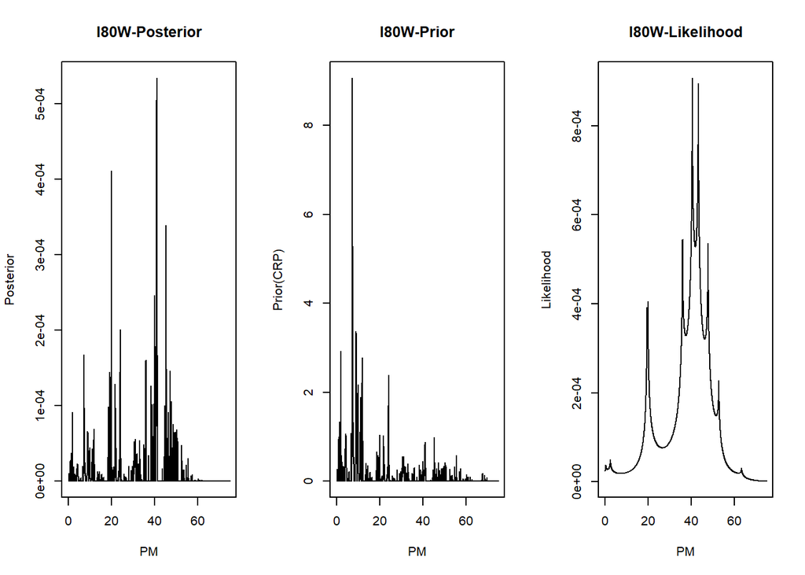

```r
i = 1 # I80W
par(mfrow =c(1,3))
plot(S_crp_pm_2006[[i]],S_post_crp_2006[[i]],type='l',xlab = "PM",ylab="Posterior",main="I80W-Posterior")
plot(S_crp_pm_2006[[i]],S_crp_2006[[i]],type='l',xlab = "PM",ylab="Prior(CRP)",main="I80W-Prior")
plot(S_crp_pm_2006[[i]],S_likelihood_2006[[i]],type='l',xlab = "PM",ylab="Likelihood",main="I80W-Likelihood")
```

## Evaluation

Prioritize the fatal collision locations based on posterior and evaluate the performance of detecting reproducible fatal collision location. The performance was compared to the random selection using ROC curve.

#### Calculate the posterior of each fatal collision location

```r
## Calculate probabilities P(D|F)
num_fatal_2006=length(acc_fatal_pm_2006)
num_fatal_2007=length(acc_fatal_pm_2007)
num_fatal_2008=length(acc_fatal_pm_2008)

l=1 # length of range for P
P_crp_deadly_2006=NULL
P_unif_deadly_2006=NULL

for(j in 1:num_fatal_2006){
  P_crp_deadly_2006[j]=sum(post_crp_2006[crp_pm_2006>=acc_fatal_pm_2006[j]-l & crp_pm_2006<=acc_fatal_pm_2006[j]+l])
  P_unif_deadly_2006[j]=sum(post_unif_2006[crp_pm_2006>=acc_fatal_pm_2006[j]-l & crp_pm_2006<=acc_fatal_pm_2006[j]+l])
}



## Site selection based on probability of deadly site
## CRP PM increament = 0.01
acc_fatal_pm_2007=c(acc_fatal_pm_2007,acc_fatal_pm_2008)
acc_fatal_count_2007=c(acc_fatal_count_2007,acc_fatal_count_2008)
win_len=1
num_sec=win_len/0.01


## Selecting deadly site from 2006 fatal collision method
### Fatal site merging within window length
fatal_site_index=((crp_pm_2006>=acc_fatal_pm_2006[1]-win_len/2) & (crp_pm_2006<=acc_fatal_pm_2006[1]+win_len/2))
for(i in 2:length(acc_fatal_pm_2006)){
  fatal_site_index=fatal_site_index | ((crp_pm_2006>=acc_fatal_pm_2006[i]-win_len/2) & (crp_pm_2006<=acc_fatal_pm_2006[i]+win_len/2))
}

fatal_site_num=NULL
index=0

k=1
for(i in 1:length(fatal_site_index)){
  if(fatal_site_index[i]){
    fatal_site_num[i]=k
    index=1
  } else if(index>0){
    index=0
    k=k+1
    fatal_site_num[i]=0
  } else {
    fatal_site_num[i]=0
  }
}

top_p_deadly_crp=matrix(nrow = max(fatal_site_num) ,ncol = 4)
for(i in 1:max(fatal_site_num)){
  top_p_deadly_crp[i,1]=min(crp_pm_2006[fatal_site_num==i])-0.005
  top_p_deadly_crp[i,2]=max(crp_pm_2006[fatal_site_num==i])+0.005
  top_p_deadly_crp[i,3]=top_p_deadly_crp[i,2]-top_p_deadly_crp[i,1]
  top_p_deadly_crp[i,4]=sum(post_crp_2006[fatal_site_num==i])/top_p_deadly_crp[i,3]
}
```

#### Prioritize reproducible fatal collision locations by posterior

- Compare the detected reproducible site to true reproducible sites

```r
top_p_deadly_crp=top_p_deadly_crp[order(top_p_deadly_crp[,4],decreasing = T),]
top=nrow(top_p_deadly_crp)
d_fatal_crp=((acc_fatal_pm_2007>=top_p_deadly_crp[1,1]) & (acc_fatal_pm_2007<=top_p_deadly_crp[1,2]))
perf_crp=sum(acc_fatal_count_2007[d_fatal_crp])#/sum(acc_fatal_count_2007)
if(perf_crp==0){
  detect_crp=0
} else {
  detect_crp=1
}
for(i in 2:top){
  d_fatal_crp=d_fatal_crp | ((acc_fatal_pm_2007>=top_p_deadly_crp[i,1]) & (acc_fatal_pm_2007<=top_p_deadly_crp[i,2]))
  perf_crp[i]=sum(acc_fatal_count_2007[d_fatal_crp])#/sum(acc_fatal_count_2007)
  if(perf_crp[i-1]==perf_crp[i]){
    detect_crp[i]=0
  } else {
    detect_crp[i]=1
  }
}

top_p_deadly_crp = as.data.frame(cbind(top_p_deadly_crp,detect_crp))
```

#### implement the random selection as a benchmark

```r
## Random selection without prior (i.e., ROC ~ 0.5)
num_try=1000
perf_rnd=NULL
detect_rnd=NULL
for(i in 1:top){
  temp_perf=NULL
  temp_detect=NULL
  for(j in 1:num_try){
    rnd_select=sample(1:top,size = i,replace = F)
    selected_site_sp=top_p_deadly_crp[rnd_select,1]
    selected_site_ep=top_p_deadly_crp[rnd_select,2]
    d_fatal_rnd=((acc_fatal_pm_2007>=selected_site_sp[1]) & (acc_fatal_pm_2007<=selected_site_ep[1]))
    if(i>=2){
      for(k in 2:i){
        d_fatal_rnd=d_fatal_rnd | ((acc_fatal_pm_2007>=selected_site_sp[k]) & (acc_fatal_pm_2007<=selected_site_ep[k]))
      }
    }
    temp_perf[j]=sum(acc_fatal_count_2007[d_fatal_rnd])#/sum(acc_fatal_count_2007)
    temp_detect[j]=sum(detect_crp[rnd_select])
  }
  perf_rnd[i]=mean(temp_perf)
  detect_rnd[i]=mean(temp_detect)
}
```

#### Plots of evaluation results

- Cumulative detected sites by posterior vs true reproducible site

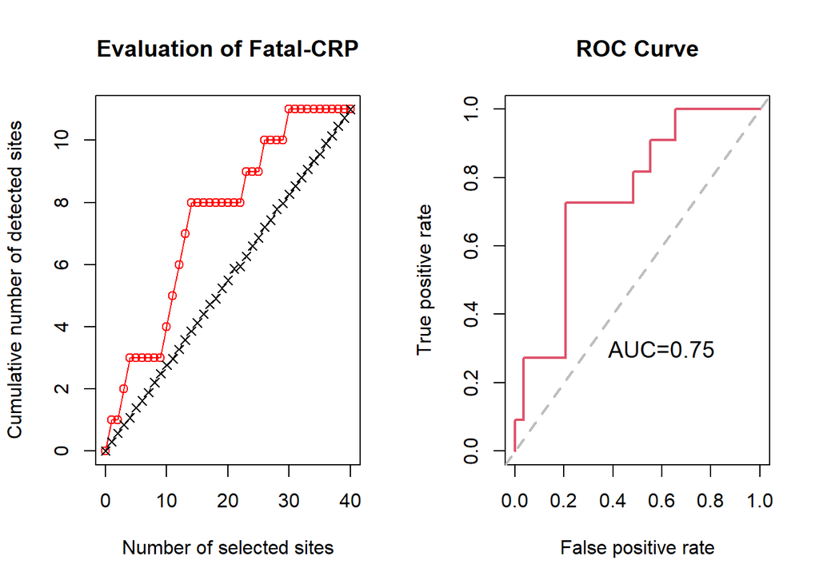

```r
par(mfrow=c(1,2))
plot(0:length(detect_crp),c(0,cumsum(detect_crp)),type='l',col='red',ylab="Cumulative number of detected sites",xlab="Number of selected sites",
     main="Evaluation of Fatal-CRP")
points(0:length(detect_crp),c(0,cumsum(detect_crp)),col='red')
lines(0:length(detect_rnd),c(0,detect_rnd), lty=2) # random selection
points(0:length(detect_rnd),c(0,detect_rnd), pch=4)

# ROC curve
pred=prediction(top_p_deadly_crp[,4],detect_crp)
perf=performance(pred,"tpr","fpr")
plot(perf,main="ROC Curve",col=2,lwd=2)
abline(a=0,b=1,lwd=2,lty=2,col="gray")
auc=performance(pred,"auc")
auc=unlist(slot(auc, "y.values"))
text(x = 0.6,y = 0.3,labels = paste("AUC=",round(auc,2),sep=""),cex = 1.2)
```

## Visualization of prior, likelihood and posterior

#### Likelihood according to fatal collision locations in I80

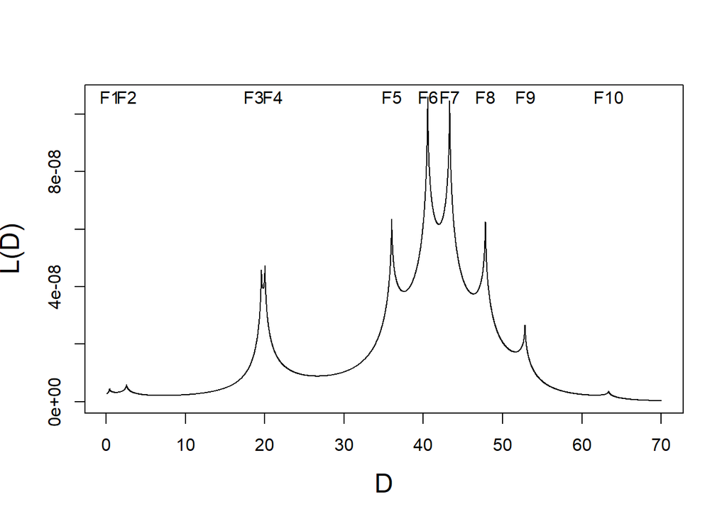

```r
par(mfrow=c(1,1))
num_fatal_2006_I80W=length(acc_fatal_pm_2006[acc_fatal_pm_2006<70])
Pf_d_2006_I80W=matrix(nrow = length(crp_pm_2006[crp_pm_2006<70]),ncol = num_fatal_2006_I80W)
for(i in 1:num_fatal_2006_I80W){
  Pf_d_2006_I80W[,i]=(1/(1+(abs(crp_pm_2006[crp_pm_2006<70] - acc_fatal_pm_2006[acc_fatal_pm_2006<70][i]))^alpha))^acc_fatal_count_2006[acc_fatal_pm_2006<70][i]
}
post_crp_2006_I80W=crp_2006[crp_pm_2006<70]*apply(Pf_d_2006_I80W,1,prod)
post_crp_2006_I80W=post_crp_2006_I80W/sum(post_crp_2006_I80W)

plot(crp_pm_2006[crp_pm_2006<70],apply(Pf_d_2006_I80W,1,prod), type="l",xlab="D",ylab="L(D)",cex.lab=1.5)
text(acc_fatal_pm_2006[c(1:2,5:10)],rep(max(apply(Pf_d_2006_I80W,1,prod)),8),labels = paste("F",1:10,sep="")[c(1:2,5:10)])
text(acc_fatal_pm_2006[3]-1,max(apply(Pf_d_2006_I80W,1,prod)),labels = paste("F",1:10,sep="")[3])
text(acc_fatal_pm_2006[4]+1,max(apply(Pf_d_2006_I80W,1,prod)),labels = paste("F",1:10,sep="")[4])
```

#### Prior vs Posterior according to fatal collision locations in I80

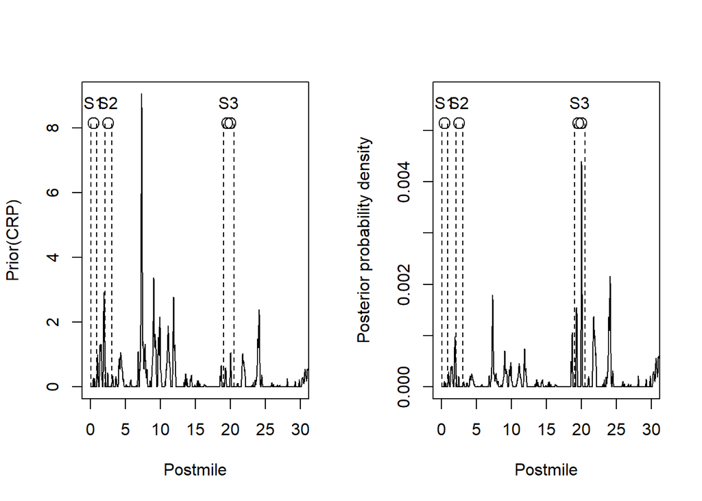

```r
par(mfrow=c(1,2))
plot(crp_pm_2006[crp_pm_2006<70],crp_2006[crp_pm_2006<70],type="l",xlim = c(0,30),xlab="Postmile",ylab="Prior(CRP)",ylim=c(0,max(crp_2006[1:7000])))
points(acc_fatal_pm_2006,rep(max(crp_2006[crp_pm_2006<70])*0.9,length(acc_fatal_pm_2006)), cex=1.5)
lines(top_p_deadly_crp[,1],rep(max(crp_2006[crp_pm_2006<70])*0.9,nrow(top_p_deadly_crp)),type='h', lty=2)
lines(top_p_deadly_crp[,2],rep(max(crp_2006[crp_pm_2006<70])*0.9,nrow(top_p_deadly_crp)),type='h', lty=2)
acc_label=paste("S",c(1:nrow(top_p_deadly_crp)),sep="")
text(x = sort((top_p_deadly_crp[,1]+top_p_deadly_crp[,2])/2), y= rep(max(crp_2006[crp_pm_2006<70])*0.97, nrow(top_p_deadly_crp)), labels = acc_label)

plot(crp_pm_2006[crp_pm_2006<70],post_crp_2006_I80W,type="l",xlim = c(0,30),xlab="Postmile",ylab="Posterior probability density",ylim=c(0,max(post_crp_2006_I80W)))
post_fun=approxfun(crp_pm_2006[crp_pm_2006<70],post_crp_2006_I80W,rule=2)
for(i in 1:nrow(top_p_deadly_crp)){
  x=c(top_p_deadly_crp[i,1],top_p_deadly_crp[i,2],top_p_deadly_crp[i,2],seq(top_p_deadly_crp[i,2]-0.005,top_p_deadly_crp[i,1]+0.005,by=-0.01),top_p_deadly_crp[i,1])
  y=c(0,0,post_fun(c(top_p_deadly_crp[i,2],seq(top_p_deadly_crp[i,2]-0.005,top_p_deadly_crp[i,1]+0.005,by=-0.01),top_p_deadly_crp[i,1])))
  polygon(x,y,col="gray",border = NA)
}
lines(crp_pm_2006[crp_pm_2006<70],post_crp_2006_I80W)
points(acc_fatal_pm_2006,rep(max(post_crp_2006_I80W[crp_pm_2006<70])*0.9,length(acc_fatal_pm_2006)), cex=1.5)
lines(top_p_deadly_crp[,1],rep(max(post_crp_2006_I80W[crp_pm_2006<70])*0.9,nrow(top_p_deadly_crp)),type='h', lty=2)
lines(top_p_deadly_crp[,2],rep(max(post_crp_2006_I80W[crp_pm_2006<70])*0.9,nrow(top_p_deadly_crp)),type='h', lty=2)
acc_label=paste("S",c(1:nrow(top_p_deadly_crp)),sep="")
text(x = sort((top_p_deadly_crp[,1]+top_p_deadly_crp[,2])/2), y= rep(max(post_crp_2006_I80W[crp_pm_2006<70])*0.97, nrow(top_p_deadly_crp)), labels = acc_label)
```